# 🐍 Python ate my Homework! 📝

## Evan Kohilas

### `@ekohilas` - `nohumanerrors.com`

[figure not shown]

## Maths Assignments

### Traditionally handwritten

[figure not shown]

### Or now, digitally written

[figure not shown]

### Or re-written with Latex

[figure not shown]

### But these could all be:

- Messy and illegible
- Tedious and time consuming
- Error prone and unvalidated
- Static and unchangeable

## Question 1: Discrete Maths

Show whether the following numbers can be represented as a sum of two squares ($n = a^2 + b^2$):

```python
q1_numbers = (
    85,
    49,
    343,
)
```

e.g.

$250 = 81 + 169$

$250 = 9^2 + 13^2$

**Theorem Reminder:**

*A positive integer $n$ can be written as a sum of two squares, if and only if there is **no** prime $p$ that;*

- *divides $n$ an odd number of times,*
- *and for which $p \ \% \ 4 = 3$.*

All the primes that *divide* $n$ are also known as *factors* of $n$.

e.g. if $n = 250$, then the factors of $250$ are:

$ \begin{align} 250 &= 2 \cdot 125 \\ &= 2 \cdot 5 \cdot 25 \\ &= 2 \cdot 5 \cdot 5 \cdot 5 \\ &= 2^1 \cdot 5^3 \\ \end{align} $

Thus we want to check if there is any $p^k$ such that $p\ \%\ 4 = 3$ and $k\ \%\ 2 = 1$.

```python
def sum_of_two_squares(n: int) -> bool:
    for p, k in factors(n):
        if k % 2 == 1 and p % 4 == 3:
            return False
    return True
```

But how do we calculate the factors?

We'll import a method from SymPy (a Python library for symbolic mathematics)

```python
from sympy import factorint
factorint(250)
```

```
{2: 1, 5: 3}
```

```python
def sum_of_two_squares(n: int) -> bool:
    factors = factorint(n)
    for prime, power in sorted(factors.items()):
        is_odd_power = power % 2 == 1
        is_3_mod_4 = prime % 4 == 3
        if is_odd_power and is_3_mod_4:
            return False
    return True

for sub_question, number in enumerate(q1_numbers, start=1):
    print(f"Q1.{sub_question}:", number, sum_of_two_squares(number), "\n")
```

```
Q1.1: 85 True

Q1.2: 49 True

Q1.3: 343 False
```

```python
def sum_of_two_squares(n: int) -> bool:
    factors = factorint(n)
    print(f"Factors of {n} are: {factors}")
    factors = factorint(n)
    for prime, power in sorted(factors.items()):
        is_odd_power = power % 2 == 1
        is_3_mod_4 = prime % 4 == 3
        print(
            f"Checking {prime}^{power}:\n"
            f"Prime {prime} % 4 = {prime % 4} "
            f"{'=' if is_3_mod_4 else '≠'} 3\n"
            f"Power {power} is {'odd' if is_odd_power else 'even'}"
        )
        if is_odd_power and is_3_mod_4:
            print(
                f"Therefore {n} cannot be written as a sum of two squares, "
                "since there is a prime p^k where k is odd and p % 4 = 3."
            )
            return False
    print(
        f"Therefore {n} can be written as a sum of two squares, "
        "since there is no prime p^k where k is odd and p % 4 = 3."
    )
    return True

for sub_question, number in enumerate(q1_numbers, start=1):
    print(f"Q1.{sub_question}:", sum_of_two_squares(number), "\n")
```

```
Factors of 85 are: {5: 1, 17: 1}
Checking 5^1:
Prime 5 % 4 = 1 ≠ 3
Power 1 is odd
Checking 17^1:
Prime 17 % 4 = 1 ≠ 3
Power 1 is odd
Therefore 85 can be written as a sum of two squares, since there is no prime p^k where k is odd and p % 4 = 3.
Q1.1: True

Factors of 49 are: {7: 2}
Checking 7^2:
Prime 7 % 4 = 3 = 3
Power 2 is even
Therefore 49 can be written as a sum of two squares, since there is no prime p^k where k is odd and p % 4 = 3.
Q1.2: True

Factors of 343 are: {7: 3}
Checking 7^3:
Prime 7 % 4 = 3 = 3
Power 3 is odd
Therefore 343 cannot be written as a sum of two squares, since there is a prime p^k where k is odd and p % 4 = 3.
Q1.3: False
```

```python
factorint(250, visual=True)
```

$\displaystyle 2^{1} \cdot 5^{3}$

```python
from sympy import Eq
```

```python
Eq(
    250,
    factorint(250, visual=True),
)
```

$\displaystyle \text{True}$

```python
Eq(
    250,
    factorint(250, visual=True),
    evaluate=False,
)
```

$\displaystyle 250 = 2^{1} \cdot 5^{3}$

```python
from IPython.display import Markdown
def sum_of_two_squares(n: int) -> bool:
    display(
        Eq(
            n,
            factorint(n, visual=True),
            evaluate=False,
        )
    )
    factors = factorint(n)
    for prime, power in sorted(factors.items()):
        is_odd_power = power % 2 == 1
        is_3_mod_4 = prime % 4 == 3
        display(Markdown(
            f"Checking ${prime}^{power}$:  \n"
            f"Prime ${prime}\\ \\%\\ 4 = {prime % 4} "
            f"{'=' if is_3_mod_4 else '≠'} 3$  \n"
            f"Power ${power}$ is {'odd' if is_odd_power else 'even'}"
        ))
        if is_odd_power and is_3_mod_4:
            display(Markdown(
                f"Therefore ${n}$ cannot be written as "
                "a sum of two squares, since there is "
                "a prime $p^k$ where $k$ is odd and $p\\ \\%\\ 4 = 3$."
            ))
            return False
    display(Markdown(
        f"Therefore ${n}$ can be written as "
        "a sum of two squares, since there is "
        "no prime $p^k$ where $k$ is odd and $p\\ \\%\\ 4 = 3$."
    ))
    return True

for sub_question, number in enumerate(q1_numbers, start=1):
    print(f"Q1.{sub_question}:", sum_of_two_squares(number), "\n")
```

$\displaystyle 85 = 17^{1} \cdot 5^{1}$

Checking $5^1$:  
Prime $5\ \%\ 4 = 1 ≠ 3$  
Power $1$ is odd

Checking $17^1$:  
Prime $17\ \%\ 4 = 1 ≠ 3$  
Power $1$ is odd

Therefore $85$ can be written as a sum of two squares, since there is no prime $p^k$ where $k$ is odd and $p\ \%\ 4 = 3$.

```
Q1.1: True
```

$\displaystyle 49 = 7^{2}$

Checking $7^2$:  
Prime $7\ \%\ 4 = 3 = 3$  
Power $2$ is even

Therefore $49$ can be written as a sum of two squares, since there is no prime $p^k$ where $k$ is odd and $p\ \%\ 4 = 3$.

```
Q1.2: True
```

$\displaystyle 343 = 7^{3}$

Checking $7^3$:  
Prime $7\ \%\ 4 = 3 = 3$  
Power $3$ is odd

Therefore $343$ cannot be written as a sum of two squares, since there is a prime $p^k$ where $k$ is odd and $p\ \%\ 4 = 3$.

```
Q1.3: False
```

```python
from sympy.solvers.diophantine.diophantine import sum_of_squares
def sum_of_two_squares(n: int) -> bool:
    display(
        Eq(
            n,
            factorint(n, visual=True),
            evaluate=False,
        )
    )
    factors = factorint(n)
    for prime, power in sorted(factors.items()):
        is_odd_power = power % 2 == 1
        is_3_mod_4 = prime % 4 == 3
        display(Markdown(
            f"Checking ${prime}^{power}$:  \n"
            f"Prime ${prime}\\ \\%\\ 4 = {prime % 4} "
            f"{'=' if is_3_mod_4 else '≠'} 3$  \n"
            f"Power ${power}$ is {'odd' if is_odd_power else 'even'}"
        ))
        if is_odd_power and is_3_mod_4:
            display(Markdown(
                f"Therefore ${n}$ cannot be written as "
                "a sum of two squares, since there is "
                "a prime $p^k$ where $k$ is odd and $p\\ \\%\\ 4 = 3$."
            ))
            return False
    square1, square2 = next(sum_of_squares(n=n, k=2, zeros=True))
    display(Markdown(
        f"Therefore ${n}$ can be written as "
        "a sum of two squares, since there is "
        "no prime $p^k$ where $k$ is odd and $p\\ \\%\\ 4 = 3$."
        f"\n\n e.g. ${n} = {square1} ^ 2 + {square2} ^ 2$"
    ))
    return True

for sub_question, number in enumerate(q1_numbers, start=1):
    print(f"Q1.{sub_question}:", sum_of_two_squares(number), "\n")
```

$\displaystyle 85 = 17^{1} \cdot 5^{1}$

Checking $5^1$:  
Prime $5\ \%\ 4 = 1 ≠ 3$  
Power $1$ is odd

Checking $17^1$:  
Prime $17\ \%\ 4 = 1 ≠ 3$  
Power $1$ is odd

Therefore $85$ can be written as a sum of two squares, since there is no prime $p^k$ where $k$ is odd and $p\ \%\ 4 = 3$.

e.g. $85 = 6 ^ 2 + 7 ^ 2$

```
Q1.1: True
```

$\displaystyle 49 = 7^{2}$

Checking $7^2$:  
Prime $7\ \%\ 4 = 3 = 3$  
Power $2$ is even

Therefore $49$ can be written as a sum of two squares, since there is no prime $p^k$ where $k$ is odd and $p\ \%\ 4 = 3$.

e.g. $49 = 0 ^ 2 + 7 ^ 2$

```
Q1.2: True
```

$\displaystyle 343 = 7^{3}$

Checking $7^3$:  
Prime $7\ \%\ 4 = 3 = 3$  
Power $3$ is odd

Therefore $343$ cannot be written as a sum of two squares, since there is a prime $p^k$ where $k$ is odd and $p\ \%\ 4 = 3$.

```
Q1.3: False
```

## Question 2: Calculus

For the following curve $y = -x^2 + 2x + 3$

1. Calculate the $x$ intersection points.
2. Calculate the $y$ intersection point.
3. Calculate the curve's vertex.
4. Plot the curve.

[What can Wolfram Alpha do?](https://www.wolframalpha.com/input?i=y+%3D+-x%5E2+%2B+2x+%2B+3)

[figure not shown]

```python
from sympy.abc import x
```

```python
y_equation = - x ** 2 + 2 * x + 3
y_equation
```

$\displaystyle - x^{2} + 2 x + 3$

```python
from sympy import Function
y = Function("y")
```

```python
Eq(
    y(x),
    y_equation,
)
```

$\displaystyle y{\left(x \right)} = - x^{2} + 2 x + 3$

### Question 2.1

Calculate the $y$ intersection point of $y = -x^2 + 2x + 3$

**Reminder:**

Thus for Q2.1, we need to substitute for $x=0$

```python
y_equation.subs(x, 0)
```

$\displaystyle 3$

```python
display(
    Eq(
        y(x),
        y_equation,
    ),
    Eq(
        y(0),
        y_equation.subs(x, 0),
    ),
)
```

$\displaystyle y{\left(x \right)} = - x^{2} + 2 x + 3$

$\displaystyle y{\left(0 \right)} = 3$

```python
from sympy import UnevaluatedExpr
```

```python
display(
    Eq(
        y(x),
        y_equation,
    ),
    Eq(
        y(0),
        y_equation.subs(x, UnevaluatedExpr(0))
    ),
    Eq(
        y(0),
        y_equation.subs(x, 0)
    ),
)
```

$\displaystyle y{\left(x \right)} = - x^{2} + 2 x + 3$

$\displaystyle y{\left(0 \right)} = 3 + 2 \cdot 0 - 0^{2}$

$\displaystyle y{\left(0 \right)} = 3$

### Question 2.2

Calculate the $x$ intersection points of $y = -x^2 + 2x + 3$

**Reminder:** *The $x$ intersection points are where $(x(0), 0)$ (where $y = 0$)*

Thus we need to re-arrange for $x$, and solve for $y=0$.

We can do this using the quadratic formula:

```python
from sympy import sympify
```

```python
quadratic = "a * x ** 2 + b * x + c"
Eq(
    y(x),
    sympify(quadratic)
)
```

$\displaystyle y{\left(x \right)} = a x^{2} + b x + c$

```python
from sympy import solve
```

```python
quadratic_solutions = solve(quadratic, "x")
display(*quadratic_solutions)
```

$\displaystyle \frac{- b - \sqrt{- 4 a c + b^{2}}}{2 a}$

$\displaystyle \frac{- b + \sqrt{- 4 a c + b^{2}}}{2 a}$

Substituting for the respective constants:

```python
display(
    Eq(
        y(x),
        sympify(quadratic),
    ),
    Eq(
        y(x),
        y_equation,
    ),
)
```

$\displaystyle y{\left(x \right)} = a x^{2} + b x + c$

$\displaystyle y{\left(x \right)} = - x^{2} + 2 x + 3$

```python
constants = {
    "a": UnevaluatedExpr(-1),
    "b": UnevaluatedExpr(2),
    "c": UnevaluatedExpr(3),
}

for solution in quadratic_solutions:
    x_solution = solution.subs(constants)
    display(
        Eq(
            x,
            x_solution,
        )
    )

    x_value = x_solution.doit()
    display(
        Eq(
            x,
            x_value,
        ),
        Eq(
            y(x_value),
            0,
        ),
    )
```

$\displaystyle x = \frac{\left(-1\right)^{-1} \left(- \sqrt{2^{2} - 4 \cdot 3 \left(-1\right)} - 2\right)}{2}$

$\displaystyle x = 3$

$\displaystyle y{\left(3 \right)} = 0$

$\displaystyle x = \frac{\left(-1\right)^{-1} \left(\sqrt{2^{2} - 4 \cdot 3 \left(-1\right)} - 2\right)}{2}$

$\displaystyle x = -1$

$\displaystyle y{\left(-1 \right)} = 0$

Of course, SymPy also has methods to fast forward this too.

```python
solve(y_equation, x)
```

```
[-1, 3]
```

### Question 2.3

Calculate the vertex of $y = -x^2 + 2x + 3$

**Reminder:** *A function $y(x)$ has a maximum point where $\frac{d}{dx}y(x) = 0$ if $y(x)\frac{d^2y}{dx^2} < 0$.*

```python
y_diff = y_equation.diff(x)
Eq(
    y(x).diff(x),
    y_diff,
)
```

$\displaystyle \frac{d}{d x} y{\left(x \right)} = 2 - 2 x$

Solving for $y = 0$

```python
solve(y_diff, x)
```

```
[1]
```

Substituting $x = 1$ to $y(x)$

```python
y_equation.subs(x, 1)
```

$\displaystyle 4$

Thus the maximum of point of $y(x)$ is at $(1, 4)$

### Question 2.4

Plot $y = -x^2 + 2x + 3$

```python
from sympy import plot
```

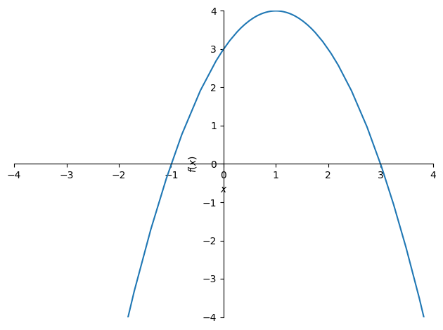

```
<sympy.plotting.plot.Plot at 0x109e429c0>
```

```python
plot(
    y_equation,
    xlim=(-4, 4),
    ylim=(-4, 4),
)
```

## Question 3: Multi-variable Calculus

The following profit function $f(u_1, u_2)$ describes the profit that results from selling $u_1$ units of Product 1 and $u_2$ units of Product 2.

$f{\left(u_{1},u_{2} \right)} = - \Delta \left(u_{1}^{2} + u_{2}^{2}\right) - c_{0} - u_{1} u_{2} \left(\Delta_{12} + \Delta_{21}\right) + u_{1} \left(- c_{1} + p_{1}\right) + u_{2} \left(- c_{2} + p_{2}\right)$

$p_1$ and $p_2$ represent, respectively, the market price (per unit) for each product.

$c_1$ and $c_2$ represent, respectively, the cost (per unit) for each product.

$c_0$ represents the fixed cost, regardless of any production or sales.

$\Delta$ represents the decrease in unit price of each product for any additional unit that is sold of that product.

$\Delta_{12}$ represents the decrease in price of Product 1 for each additional unit that is sold of Product 2 (and vice versa for $\Delta_{21}$).

**Assuming that a unique solution exists and is extremal, find the optimal profit for the following parameters:**

$p_1 = \$400$

$p_2 = \$600$

$c_1 = \$200$

$c_2 = \$300$

$c_0 = \$500,000$

$\Delta = \$0.02$

$\Delta_{12} = \$0.001$

$\Delta_{21} = \$0.002$

[What can Wolfram Alpha do if we help it out?](https://www.wolframalpha.com/input?i=maximum+of+-+0.02+*+%28u%5E2+%2B+v%5E2%29+-+500000+-+u+*+v+*+%280.001+%2B+0.002%29+%2B+u+*+%28-+200+%2B+400%29+%2B+v+*+%28-+300+%2B+600%29)

[figure not shown]

```python
from sympy import symbols
u1, u2 = symbols("u_1 u_2")
c0, c1, c2 = symbols("c:3")
p1, p2 = symbols("p_1 p_2")
D, D12, D21 = symbols("Delta Delta_12 Delta_21")
```

```python
equation = (
    -c0
    + u1 * (p1 - c1)
    + u2 * (p2 - c2)
    - u1 * u2 * (D12 + D21)
    - D * (u1 ** 2 + u2 ** 2)
)
```

```python
from sympy import Function
f = Function("f")
```

```python
Eq(
    f(u1, u2),
    equation,
)
```

$\displaystyle f{\left(u_{1},u_{2} \right)} = - \Delta \left(u_{1}^{2} + u_{2}^{2}\right) - c_{0} - u_{1} u_{2} \left(\Delta_{12} + \Delta_{21}\right) + u_{1} \left(- c_{1} + p_{1}\right) + u_{2} \left(- c_{2} + p_{2}\right)$

```python
constants = {
    p1: 400,
    p2: 600,
    c1: 200,
    c2: 300,
    c0: 500_000,
    D: 0.02,
    D12: 0.001,
    D21: 0.002,
}
```

**Reminder:**

The maximum value of $f$ is where $\nabla f = \bf 0$

Where $\nabla f(x,y) = \left[\begin{matrix}\frac{\partial}{\partial x} f(x,y)\\\frac{\partial}{\partial y} f(x,y)\end{matrix}\right]$

Thus, to find the optimal profit, we must find the maximum, by finding the values $u^\ast_1$, $u^\ast_2$ for which $\nabla f(u^\ast_1, u^\ast_2) = \bf 0$.

```python
from sympy import Matrix

f_diff_wrt_u1_unevaluated = equation.diff(u1, evaluate=False)
f_diff_wrt_u2_unevaluated = equation.diff(u2, evaluate=False)

f_diff_wrt_u1 = f_diff_wrt_u1_unevaluated.doit()
f_diff_wrt_u2 = f_diff_wrt_u2_unevaluated.doit()

display(
    Eq(
        Matrix([
            f(u1, u2).diff(u1),
            f(u1, u2).diff(u2),
        ]),
        Matrix([
            f_diff_wrt_u1_unevaluated,
            f_diff_wrt_u2_unevaluated,
        ]),
    ),
    Eq(
        Matrix([0, 0]),
        Matrix([
            f_diff_wrt_u1_unevaluated,
            f_diff_wrt_u2_unevaluated,
        ]),
    ),
    Eq(
        Matrix([0, 0]),
        Matrix([
            f_diff_wrt_u1,
            f_diff_wrt_u2,
        ]),
    ),
)
```

$\displaystyle \left[\begin{matrix}\frac{\partial}{\partial u_{1}} f{\left(u_{1},u_{2} \right)}\\\frac{\partial}{\partial u_{2}} f{\left(u_{1},u_{2} \right)}\end{matrix}\right] = \left[\begin{matrix}\frac{\partial}{\partial u_{1}} \left(- \Delta \left(u_{1}^{2} + u_{2}^{2}\right) - c_{0} - u_{1} u_{2} \left(\Delta_{12} + \Delta_{21}\right) + u_{1} \left(- c_{1} + p_{1}\right) + u_{2} \left(- c_{2} + p_{2}\right)\right)\\\frac{\partial}{\partial u_{2}} \left(- \Delta \left(u_{1}^{2} + u_{2}^{2}\right) - c_{0} - u_{1} u_{2} \left(\Delta_{12} + \Delta_{21}\right) + u_{1} \left(- c_{1} + p_{1}\right) + u_{2} \left(- c_{2} + p_{2}\right)\right)\end{matrix}\right]$

$\displaystyle \left[\begin{matrix}0\\0\end{matrix}\right] = \left[\begin{matrix}\frac{\partial}{\partial u_{1}} \left(- \Delta \left(u_{1}^{2} + u_{2}^{2}\right) - c_{0} - u_{1} u_{2} \left(\Delta_{12} + \Delta_{21}\right) + u_{1} \left(- c_{1} + p_{1}\right) + u_{2} \left(- c_{2} + p_{2}\right)\right)\\\frac{\partial}{\partial u_{2}} \left(- \Delta \left(u_{1}^{2} + u_{2}^{2}\right) - c_{0} - u_{1} u_{2} \left(\Delta_{12} + \Delta_{21}\right) + u_{1} \left(- c_{1} + p_{1}\right) + u_{2} \left(- c_{2} + p_{2}\right)\right)\end{matrix}\right]$

$\displaystyle \left[\begin{matrix}0\\0\end{matrix}\right] = \left[\begin{matrix}- 2 \Delta u_{1} - c_{1} + p_{1} - u_{2} \left(\Delta_{12} + \Delta_{21}\right)\\- 2 \Delta u_{2} - c_{2} + p_{2} - u_{1} \left(\Delta_{12} + \Delta_{21}\right)\end{matrix}\right]$

Solving for $u_1$

```python
f_diff_wrt_u1_solved_for_u1 = solve(
    f_diff_wrt_u1,
    u1,
)[0]

Eq(
    u1,
    f_diff_wrt_u1_solved_for_u1
)
```

$\displaystyle u_{1} = \frac{- \Delta_{12} u_{2} - \Delta_{21} u_{2} - c_{1} + p_{1}}{2 \Delta}$

Substituting $u_1$ into $\frac{\partial}{\partial u_2} f(u_1,u_2)$

```python
f_diff_wrt_u2_removed_u1 = f_diff_wrt_u2.subs(
    u1,
    f_diff_wrt_u1_solved_for_u1
)
Eq(
    0,
    f_diff_wrt_u2_removed_u1,
)
```

$\displaystyle 0 = - 2 \Delta u_{2} - c_{2} + p_{2} - \frac{\left(\Delta_{12} + \Delta_{21}\right) \left(- \Delta_{12} u_{2} - \Delta_{21} u_{2} - c_{1} + p_{1}\right)}{2 \Delta}$

Solving for $u^\ast_2$

```python
u2s = symbols("u^*_2")
f_diff_wrt_u2_solved_for_u2 = solve(
    f_diff_wrt_u2_removed_u1,
    u2
)[0]

Eq(
    u2s,
    f_diff_wrt_u2_solved_for_u2
)
```

$\displaystyle u^{*}_{2} = \frac{2 \Delta c_{2} - 2 \Delta p_{2} - \Delta_{12} c_{1} + \Delta_{12} p_{1} - \Delta_{21} c_{1} + \Delta_{21} p_{1}}{- 4 \Delta^{2} + \Delta_{12}^{2} + 2 \Delta_{12} \Delta_{21} + \Delta_{21}^{2}}$

Substituting the constants

```python
u2s_value = f_diff_wrt_u2_solved_for_u2.subs(constants)
Eq(
    u2s,
    u2s_value
)
```

$\displaystyle u^{*}_{2} = 7165.30483972345$

We can now similarly solve for $u^*_1$ but by using a function!

```python
from sympy import Expr
from sympy import Symbol

def calculate_maximum(
    equation: Expr,
    function: Function,
    parameter1: Symbol,
    parameter2: Symbol,
    output_symbol1: Symbol,
    output_symbol2: Symbol,
    constants: dict[Symbol, float | int],
) -> dict[Symbol, float | int]:
    f = function
    v1 = parameter1
    v2 = parameter2
    v1s = output_symbol1
    v2s = output_symbol2

    f_grad = Matrix([
        f(v1, v2).diff(v1),
        f(v1, v2).diff(v2),
    ])

    display(
        Eq(
            f_grad,
            Matrix([
                equation.diff(v1, evaluate=False),
                equation.diff(v2, evaluate=False),
            ]),
            evaluate=False,
        )
    )

    f_diff_wrt = {
        v1: equation.diff(v1),
        v2: equation.diff(v2),
    }
    f_diff = Matrix(
        list(f_diff_wrt.values())
    )
    display(
        Eq(
            f_grad,
            f_diff,
        ),
        Eq(
            Matrix([
                0,
                0
            ]),
            f_diff,
        )
    )

    values = {}
    for v, u, output_symbol in (
        (v1, v2, output_symbol2),
        (v2, v1, output_symbol1)
    ):
        f_diff_wrt_v_solved_for_v = solve(
            f_diff_wrt[v],
            v,
        )[0]

        display(
            Eq(
                v,
                f_diff_wrt_v_solved_for_v,
            )
        )


        f_diff_wrt_u_removed_v = f_diff_wrt[u].subs(
            v,
            f_diff_wrt_v_solved_for_v,
        )
        display(
            Eq(
                0,
                f_diff_wrt_u_removed_v,
            )
        )

        f_diff_wrt_u_solved_for_u = solve(
            f_diff_wrt_u_removed_v,
            u
        )[0]

        display(
            Eq(
                output_symbol,
                f_diff_wrt_u_solved_for_u
            )
        )

        value = f_diff_wrt_u_solved_for_u.subs(constants)
        display(
            Eq(
                output_symbol,
                value,
            )
        )
        values[u] = value

    return values

u1s = symbols("u^*_1")
u2s = symbols("u^*_2")

values = calculate_maximum(
    equation=equation,
    function=f,
    parameter1=u1,
    parameter2=u2,
    output_symbol1=u1s,
    output_symbol2=u2s,
    constants=constants,
)

display(
    Eq(
        Matrix([
            u1s,
            u2s,
        ]),
        Matrix([
            values[u1],
            values[u2],
        ])
    )
)
```

$\displaystyle \left[\begin{matrix}\frac{\partial}{\partial u_{1}} f{\left(u_{1},u_{2} \right)}\\\frac{\partial}{\partial u_{2}} f{\left(u_{1},u_{2} \right)}\end{matrix}\right] = \left[\begin{matrix}\frac{\partial}{\partial u_{1}} \left(- \Delta \left(u_{1}^{2} + u_{2}^{2}\right) - c_{0} - u_{1} u_{2} \left(\Delta_{12} + \Delta_{21}\right) + u_{1} \left(- c_{1} + p_{1}\right) + u_{2} \left(- c_{2} + p_{2}\right)\right)\\\frac{\partial}{\partial u_{2}} \left(- \Delta \left(u_{1}^{2} + u_{2}^{2}\right) - c_{0} - u_{1} u_{2} \left(\Delta_{12} + \Delta_{21}\right) + u_{1} \left(- c_{1} + p_{1}\right) + u_{2} \left(- c_{2} + p_{2}\right)\right)\end{matrix}\right]$

$\displaystyle \left[\begin{matrix}\frac{\partial}{\partial u_{1}} f{\left(u_{1},u_{2} \right)}\\\frac{\partial}{\partial u_{2}} f{\left(u_{1},u_{2} \right)}\end{matrix}\right] = \left[\begin{matrix}- 2 \Delta u_{1} - c_{1} + p_{1} - u_{2} \left(\Delta_{12} + \Delta_{21}\right)\\- 2 \Delta u_{2} - c_{2} + p_{2} - u_{1} \left(\Delta_{12} + \Delta_{21}\right)\end{matrix}\right]$

$\displaystyle \left[\begin{matrix}0\\0\end{matrix}\right] = \left[\begin{matrix}- 2 \Delta u_{1} - c_{1} + p_{1} - u_{2} \left(\Delta_{12} + \Delta_{21}\right)\\- 2 \Delta u_{2} - c_{2} + p_{2} - u_{1} \left(\Delta_{12} + \Delta_{21}\right)\end{matrix}\right]$

$\displaystyle u_{1} = \frac{- \Delta_{12} u_{2} - \Delta_{21} u_{2} - c_{1} + p_{1}}{2 \Delta}$

$\displaystyle 0 = - 2 \Delta u_{2} - c_{2} + p_{2} - \frac{\left(\Delta_{12} + \Delta_{21}\right) \left(- \Delta_{12} u_{2} - \Delta_{21} u_{2} - c_{1} + p_{1}\right)}{2 \Delta}$

$\displaystyle u^{*}_{2} = \frac{2 \Delta c_{2} - 2 \Delta p_{2} - \Delta_{12} c_{1} + \Delta_{12} p_{1} - \Delta_{21} c_{1} + \Delta_{21} p_{1}}{- 4 \Delta^{2} + \Delta_{12}^{2} + 2 \Delta_{12} \Delta_{21} + \Delta_{21}^{2}}$

$\displaystyle u^{*}_{2} = 7165.30483972345$

$\displaystyle u_{2} = \frac{- \Delta_{12} u_{1} - \Delta_{21} u_{1} - c_{2} + p_{2}}{2 \Delta}$

$\displaystyle 0 = - 2 \Delta u_{1} - c_{1} + p_{1} - \frac{\left(\Delta_{12} + \Delta_{21}\right) \left(- \Delta_{12} u_{1} - \Delta_{21} u_{1} - c_{2} + p_{2}\right)}{2 \Delta}$

$\displaystyle u^{*}_{1} = \frac{2 \Delta c_{1} - 2 \Delta p_{1} - \Delta_{12} c_{2} + \Delta_{12} p_{2} - \Delta_{21} c_{2} + \Delta_{21} p_{2}}{- 4 \Delta^{2} + \Delta_{12}^{2} + 2 \Delta_{12} \Delta_{21} + \Delta_{21}^{2}}$

$\displaystyle u^{*}_{1} = 4462.60213702074$

$\displaystyle \left[\begin{matrix}u^{*}_{1}\\u^{*}_{2}\end{matrix}\right] = \left[\begin{matrix}4462.60213702074\\7165.30483972345\end{matrix}\right]$

Substituting to get the profit at the maximum point

```python
all_values = {
    u1: values[u1],
    u2: values[u2],
    **constants,
}
equation.subs(all_values)
```

$\displaystyle 1021055.93966059$

## Appendix

- sympy.org

[figure not shown]

- [Contribute @ github.com/sympy/sympy](https://github.com/sympy/sympy)

[figure not shown]

- [jupyter.org](https://jupyter.org/)
- [Submitting](https://github.com/ekohilas/python-ate-my-homework/python_ate_my_homework_pycon_us_2024.html)
- [Links @ python-ate-my-homework.nohumanerrors.com](https://python-ate-my-homework.nohumanerrors.com)

[figure not shown]

- `@ekohilas` - `nohumanerrors.com`
- Feedback!
- Thanks to my partner, friends, and you for watching! ❤️
- Questions?

## FAQ

**Why is using the `factorint` function from SymPy okay?**

Well, most calculators have a factorisation button.

[figure not shown]

And we're allowed them in an exam so 🤷

**Why is using the `diff` method from SymPy okay?**

At this level of mathematics, there's a mutual understanding that we know how to differentiate equations, and doing so by hand is fiddly, repetitive, and error prone, which is what we're trying to avoid.

SymPy, just like any tool used inappropriately, will cause harm.

**Isn't this entire process cheating?**

I argue that implementing this process as code solidifies one's understanding of the theory, and doing simple, mundane, and repetitive calculations does not.

That being said, someone who is dependent on this and uses it in place of learning, shouldn't expect to do well in an exam environment.

**Isn't solving the multi-variable equation again redundant?**

Yes, you could substitute the value back in to get the value of $u_1$. The point being made is that it can be easier to repeat the method with changed variables, and generalise it for other situations, rather than using more maths.

If you did want to do that, the code is:

```python
f_diff_wrt_u1_solved_for_u1.subs({**constants, u2:u2s_value})
```

$\displaystyle 4462.60213702074$

**Why does the equation for Q3 break for specific numbers?**

In the interests of presenting on time, the example for Q3 assumes that these cases will be ignored.

**How would you plot the 3D curve?**

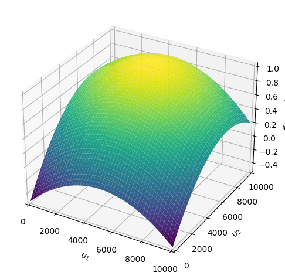

```
<sympy.plotting.plot.Plot at 0x1098d4ad0>
```

```python
from sympy.plotting.plot import plot3d
plot3d(
    equation.subs(constants),
    (u1, 0, 10_000),
    (u2, 0, 10_000),
)
```